# PlantNGSTools使用说明

# 1 软件包安装

## 1.1 安装PlantNGSTools

```
devtools::install_github('biomarble/PlantNGSTools',upgrade=F)
```

如果GitHub访问有问题，可以使用下面的命令安装

```
devtools::install_url('https://archive.fastgit.org/biomarble/PlantNGSTools/archive/main.zip',upgrade = F)
```

## 1.2 修复EBSeq bug

由于EBSeq的依赖包 `blockmodeling` 作者名字包含特殊字符，在中文的windows下加载会报错 因此，使用如下方式修复此bug:

```
file.copy(system.file('replacement','CITATION',package='PlantNGSTools'),find.package('blockmodeling'),overwrite=T)
```

# 2 加载软件包

```
library(PlantNGSTools)
```

本软件使用到的示例文件，可用如下命令拷贝到当前目录：

```
file.copy(system.file('demo','',package = 'PlantNGSTools'),'.',overwrite = T,recursive = T)
```

# 3 差异分析

## 3.1 输入文件读取

### 3.1.1 基因表达量Count文件

差异分析软件（DESeq2和EBSeq）的输入文件并非标准化后的FPKM或TPM矩阵文件，而是未标准化前的read count矩阵文件。

其中，每行为一个基因，每列为一个样本：

```r
count = read.delim("demo/count.txt", header = T, sep = "\t", row.names = 1)
```

|  | S1 | S2 | S3 | S4 | S5 | S6 | S7 | S8 | S9 |
| --- | --- | --- | --- | --- | --- | --- | --- | --- | --- |
| Os01g0100200 | 1 | 0 | 0 | 0 | 1 | 0 | 2 | 1 | 0 |
| Os01g0100400 | 344 | 330 | 415 | 345 | 306 | 477 | 435 | 488 | 284 |
| Os01g0100466 | 0 | 0 | 0 | 0 | 0 | 0 | 0 | 0 | 0 |
| Os01g0100500 | 1281 | 1213 | 1406 | 912 | 1025 | 1329 | 1111 | 1336 | 769 |
| Os01g0100600 | 101 | 108 | 118 | 84 | 80 | 106 | 93 | 129 | 78 |
| Os01g0100900 | 1157 | 1025 | 1066 | 787 | 1051 | 1051 | 951 | 1182 | 613 |

### 3.1.2 样本分组文件

对于有生物学重复样本的情况，必须输入样本分组信息文件， 其中包含了每个样本的分组所属，同一个分组内的样本互为生物学重复。 差异表达分析时，会直接使用组名指定差异分组。

```r
group = read.delim("demo/group.txt", header = T, sep = "\t")
```

| Sample | Group |
| --- | --- |
| S1 | A |
| S2 | A |
| S3 | A |
| S4 | B |
| S5 | B |
| S6 | B |
| S7 | C |
| S8 | C |
| S9 | C |

## 3.2 差异表达分析

### 3.2.1 有生物学重复-DESeq2

对于有生物学重复的情况，使用DESeq2软件分析。 参数中control和treat用于定义对照组和处理组的组名，如果不输入此两个参数则进入交互模式。

```r
resultFilePath = DEGAnalysis_DESeq2(count, group, outdir = "output", useFDR = F, cut = 0.05, FCcut = 2, control = "A", treat = "B")
```

```
差异基因分析结果见以下目录:
output/A.vs.B.AllGene.tsv
output/A.vs.B.DEG.tsv
output/A.vs.B.DEGlist.tsv
```

差异分析结果，保存在outdir定义的文件夹下

| 文件名 | 含义 |
| --- | --- |
| A.vs.B.AllGene.tsv | 所有基因的log2FC，Pvalue等信息文件 |
| A.vs.B.DEG.tsv | 差异基因文件，包含基因的log2FC，Pvalue等信息 |
| A.vs.B.DEGlist.tsv | 差异基因列表，仅有差异基因名称 |

其中文件名中`.vs.`前面的A为control组，vs后面的B为case组，$log_2FoldChange$的计算方法为：
$$log_2(Fold\ Change) =
log_2\frac{Expression(Case)}{Expression(Control)}$$

DEGAnalysis_DESeq2差异分析结果`resultFilePath`中包含了所有基因文件`resultFilePath$allgene`，以及差异基因文件`resultFilePath$deg`。

读取差异分析结果如下：

```r
allgenes = read.delim(resultFilePath$allgene, header = T, row.names = 1)
degs = read.delim(resultFilePath$deg, header = T, row.names = 1)
```

|  | S1 | S2 | S3 | S4 | S5 | S6 | MeanExpression | log2FoldChange | Pvalue | FDR |
| --- | --- | --- | --- | --- | --- | --- | --- | --- | --- | --- |
| Os01g0111700 | 78.796912 | 12.244902 | 19.766978 | 6.259099 | 16.000699 | 5.3400162 | 23.06810 | -2.018871 | 0.0142885 | 0.1371295 |
| Os01g0112400 | 259.296814 | 13.186818 | 79.067911 | 594.614457 | 3360.146851 | 180.6705496 | 747.83057 | 3.556148 | 0.0117534 | 0.1230981 |
| Os01g0112600 | 92.540559 | 60.282594 | 21.485845 | 11.266379 | 1.230823 | 0.8900027 | 31.28270 | -3.755901 | 0.0000148 | 0.0010328 |
| Os01g0117500 | 5.497459 | 1.883831 | 7.734904 | 17.525479 | 24.616460 | 15.1300460 | 12.06470 | 1.906998 | 0.0107076 | 0.1168868 |
| Os01g0121600 | 1401.852035 | 815.698851 | 184.778270 | 386.812352 | 158.776170 | 131.7204007 | 513.27301 | -1.827102 | 0.0363427 | 0.2373220 |
| Os01g0123900 | 50.393374 | 128.100512 | 31.799051 | 27.540038 | 13.539053 | 31.1500948 | 47.08702 | -1.532813 | 0.0091684 | 0.1070213 |

### 3.2.2 无生物学重复-EBSeq

对于无生物学重复的情况，可以使用EBSeq进行差异分析。

指定control的样本名和treat的样本名，如果不输入此两个参数则进入交互模式。

```r
resultFilePath = DEGAnalysis_EBSeq(count, outdir = "output", cut = 0.05, FCcut = 2, control = "S1", treat = "S2")
```

```
Removing transcripts with 100 th quantile < = 0
14516 transcripts will be tested
差异基因分析结果见以下目录:
output/S1.vs.S2.AllGene.tsv
output/S1.vs.S2.DEG.tsv
output/S1.vs.S2.DEGlist.tsv
```

```r
allgenes = read.delim(resultFilePath$allgene, header = T, row.names = 1)
degs = read.delim(resultFilePath$deg, header = T, row.names = 1)
```

|  | S1 | S2 | MeanExpression | log2FoldChange | FDR |
| --- | --- | --- | --- | --- | --- |
| Os01g0111700 | 84.69305 | 13.200611 | 48.94683 | -2.632023 | 0.0000000 |
| Os01g0112400 | 278.69922 | 14.216043 | 146.45763 | -4.241132 | 0.0000000 |
| Os01g0123900 | 54.16416 | 138.098700 | 96.13143 | 1.341436 | 0.0001719 |
| Os01g0127600 | 1952.86414 | 7937.628966 | 4945.24656 | 2.022810 | 0.0000000 |
| Os01g0614300 | 315.13693 | 136.067837 | 225.60238 | -1.208344 | 0.0000004 |
| Os01g0677400 | 24.62007 | 2.030863 | 13.32547 | -3.285424 | 0.0056083 |

## 3.3 差异基因分析绘图

### 3.3.1 火山图

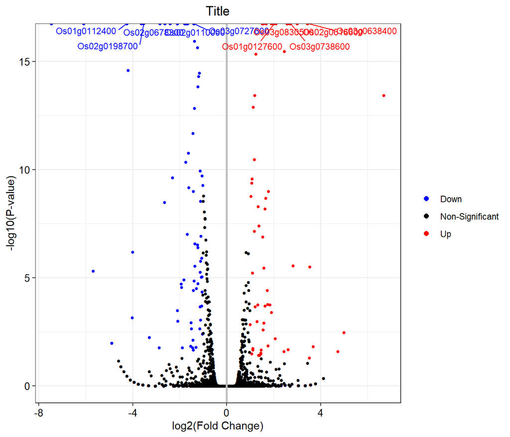

| 选项 | 含义 | 可选范围 |
| --- | --- | --- |
| showlabel | 是否显示显著基因的名称 | “allSig”：标注所有显著基因; ‘topPvalue’：标注Pvalue最小的基因; ‘topFC’：标注FC最大的基因; ‘no’:不标注 |
| showlabel.num | 指定显示的基因数目 当showlabel为topPvalue或topFC时有效 | 整数数字 |
| xlim | x轴显示范围 | 整数数字 |
| useFDR | 是否使用FDR作为显著性 具体显著性阈值由cut和FCcut来定义 | T或F |
| cut | 显著性阈值，当useFDR=T时表示FDR阈值 当useFDR=F时表示Pvalue阈值 | 0~1的小数 |
| FCcut | FoldChange阈值 | 大于1的任意数字 |
| MainTitle | 图片的标题 | 字符串 |

```r
VolcanoPlot(allgenes, useFDR = T, cut = 0.05, FCcut = 2, MainTitle = "Title", showlabel = "topPvalue", showlabel.num = 10, xlim = 10)
```

### 3.3.2 MA图

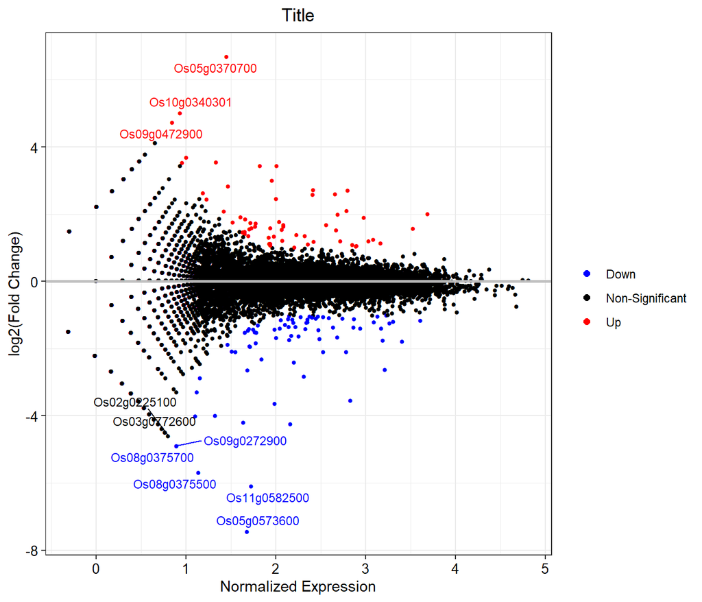

[output not shown]

```r
MAPlot(allgenes, useFDR = T, cut = 0.05, FCcut = 2, MainTitle = "Title", showlabel = "topFC", showlabel.num = 10, ylim = 10)
```

# 4 富集分析

## 4.1 常见物种富集分析

### 4.1.1 KEGG Pathway富集分析

#### 4.1.1.1 查看KEGG数据库中的物种信息

本软件包中已包含了常用物种的KEGGpathway信息，可直接通过参数指定调用，可以通过如下命令查看目前包含了哪些物种：

```r
KEGGdbInfo()
```

```
  taxon      ReferenceGenomeVersion   update           IDformat
    osa                   IRGSP-1.0 20210518       Os05g0375100
    ath                      TAIR10 20210518          AT1G01090
    mdm                 ASM211411v1 20210518       MD17G0149700
    pop                  Pop_tri_v3 20210518 POPTR_001G122400v3
    sbi      Sorghum_bicolor_NCBIv3 20210518  SORBI_3008G059900
    sly                       SL3.0 20210518   Solyc09g064370.3
 zma.V4               B73 RefGen_v4 20210518     Zm00001d042869
 zma.V5    Zm-B73-REFERENCE-NAM-5.0 20210518    Zm00001eb148000
    gmx            Glycine_max_v2.1 20210613    GLYMA_19G000700
    pca Pogostemon_Cablin_sdata2018 20210615         Pcab093315
```

#### 4.1.1.2 KEGG pathway富集分析

```r
deg = read.delim("demo/demo.rice.deg.txt", header = F)$V1
KEGGresult = KEGGenrich(deglist = deg, useFDR = F, taxon = "osa", outdir = "output", outprefix = "demo.osa")
```

```
Enrichment Done! Result files saved:
output/demo.osa.tsv
output/demo.osa.html
```

| 选项 | 含义 | 可选范围 |
| --- | --- | --- |
| deglist | 差异基因列表变量 | 必填 |
| taxon | 物种简称 | KEGGdbInfo()结果中taxon列 |
| useFDR | 是否使用FDR作为显著性 具体显著性阈值由cut来定义 | T或F |
| outdir | 输出结果目录 | 必填 |
| outprefix | 输出结果文件前缀 | 必填 |

#### 4.1.1.3 KEGG富集结果

```r
head(KEGGresult)
```

|  | ID | Pathway | DEGsInPathway | GenesInPathway | Pvalue |
| --- | --- | --- | --- | --- | --- |
| 21025 | osa01110 | Biosynthesis of secondary metabolites | 33 | 950 | 0.0015104 |
| 14827 | osa01100 | Metabolic pathways | 47 | 1658 | 0.0076116 |
| 13605 | osa00940 | Phenylpropanoid biosynthesis | 9 | 162 | 0.0077934 |
| 3002 | osa00073 | Cutin, suberine and wax biosynthesis | 3 | 20 | 0.0086401 |
| 13301 | osa00906 | Carotenoid biosynthesis | 3 | 23 | 0.0128104 |
| 8632 | osa00520 | Amino sugar and nucleotide sugar metabolism | 7 | 121 | 0.0151567 |

网页输出文件除了包含以上信息之外，具有如下额外内容：  
1. pathway中高亮标出差异基因  
2. DEGsInPathway和GenesInPathway对应的详细基因列表

[示例网页文件链接](https://blog.ugeneyun.cn/software/keggenrich.demo.osa.html)

#### 4.1.1.4 KEGG富集气泡图作图

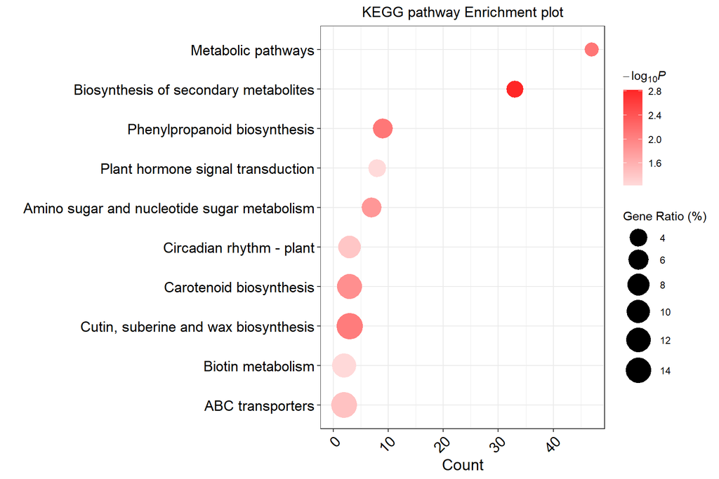

| 选项 | 含义 | 可选范围 |
| --- | --- | --- |
| dataset | KEGGenrich获得的注释结果变量 | 必填 |
| top | 输出BP、MF、CC分别的前n个功能节点 最终输出的功能同时满足top与cut参数 | >1即可 |
| MainTitle | 图片标题 | 任意字符串 |
| xangle | X轴文字旋转角度 | 30,45,90 |
| ColorScheme | 颜色方案 | ryb, rwb, ryg, rwg, rw, bw, gw 其中r为红色，y为黄色，w为白色，b为蓝色，g为绿色 |
| ColorReverse | 是否反转ColorScheme的颜色的顺序 | T或F |
| TrimName | 是否对名称特别长的Pathway名称进行剪切缩短 | T或F |
| NameWidth | 如果 TrimName为T，则直接剪切前NameWidth个字符，否则按照NameWidth长度自动换行 | 默认为50 |

```r
KEGGbubble(dataset = KEGGresult, top = 10, MainTitle = "KEGG pathway Enrichment plot", xangle = 45, TrimName = F, NameWidth = 50, ColorScheme = "rw", ColorReverse = F)
```

### 4.1.2 GO富集分析

#### 4.1.2.1 查看GO数据库中的物种信息

本软件包中已包含了常用物种的GO注释信息，通过如下命令查看：

```r
GOdbInfo()
```

[output not shown]

#### 4.1.2.2 GO富集分析

```r
deg = read.delim("demo/demo.rice.deg.txt", header = F)$V1
GOresult = GOEnrich(deglist = deg, taxon = "osa", useFDR = F, cut = 0.05, outdir = "output", outprefix = "demo.osa")
```

```
genome version: IRGSP-1.0
Processing BP class.........done!
Processing MF class.........done!
Processing CC class.........done!

GO enrichment Done!
Result files saved at:
output/demo.osa.GO.significant.tsv
output/demo.osa.GO.all.tsv
```

| 选项 | 含义 | 可选范围 |
| --- | --- | --- |
| deglist | 差异基因列表变量 | 必填 |
| taxon | 物种简称 | GOdbInfo()结果中taxon列 |
| useFDR | 是否使用FDR作为显著性 具体显著性阈值由cut来定义 | T或F |
| cut | 显著性阈值，当useFDR=T时表示FDR阈值 当useFDR=F时表示Pvalue阈值 | 0~1的小数 |
| outdir | 输出结果目录 | 必填 |
| outprefix | 输出结果文件前缀 | 必填 |

#### 4.1.2.3 GO富集气泡图作图

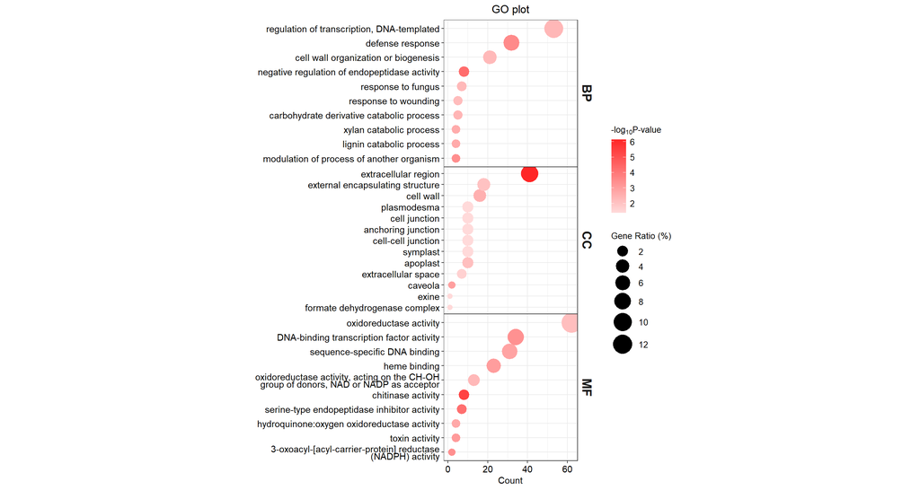

| 选项 | 含义 | 可选范围 |
| --- | --- | --- |
| dataset | GOEnrich获得的注释结果变量 | 必填 |
| onlySig | 是否只显示显著的功能节点 |  |
| useFDR | 是否使用FDR作为显著性 具体显著性阈值由cut来定义 | T或F |
| cut | 显著性阈值，当useFDR=T时表示FDR阈值 当useFDR=F时表示Pvalue阈值 | 0~1的小数 |
| top | 输出BP、MF、CC分别的前n个功能节点 最终输出的功能同时满足top与cut参数 | >1即可 |
| MainTitle | 图片标题 | 任意字符串 |
| ColorScheme | 颜色方案 | ryb, rwb, ryg, rwg, rw, bw, gw 其中r为红色，y为黄色，w为白色，b为蓝色，g为绿色 |
| ColorReverse | 是否反转ColorScheme的颜色的顺序 | T或F |
| TrimTerm | 是否对长名称的Term进行剪切缩短 | T或F |
| TermWidth | 如果 TrimTerm为T，则直接剪切前TermWidth个字符，否则按照TermWidth长度自动换行 | 默认为60 |

```r
GObubble(dataset = GOresult, onlySig = T, useFDR = F, cut = 0.05, top = 10, TrimTerm = F, TermWidth = 50, MainTitle = "GO plot", ColorScheme = "rw", ColorReverse = F)
```

#### 4.1.2.4 GO二级节点注释条形图

绘制GO数据库的所有二级节点的所有基因与差异基因条形图：

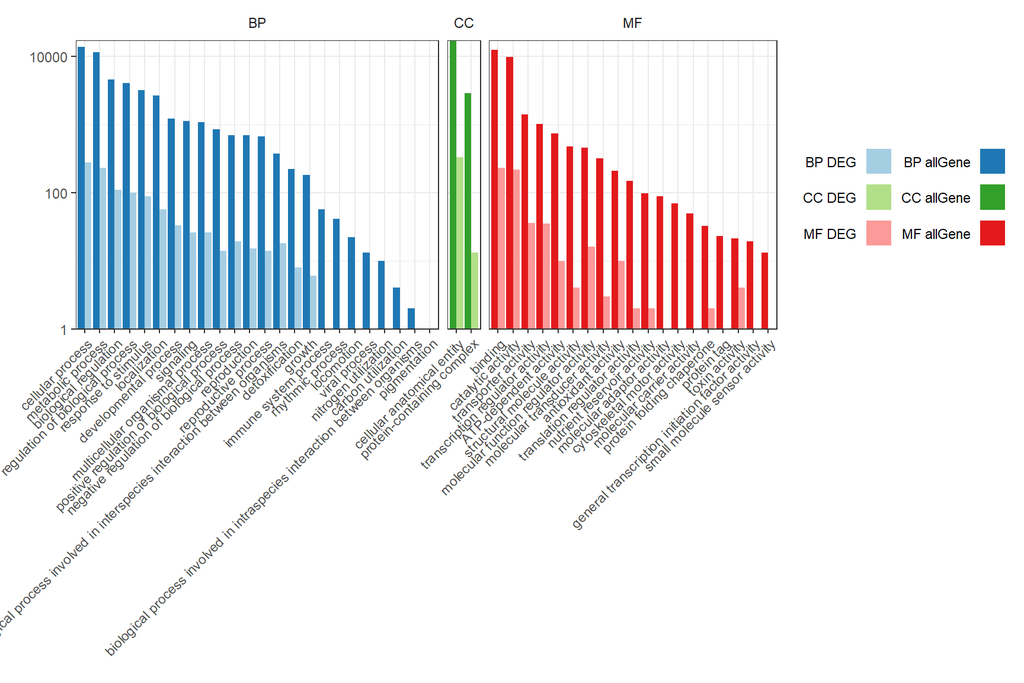

```r
GOBar(deg, taxonid = "osa")
```

## 4.2 自定义注释的富集分析（无参物种，或自注释物种）

### 4.2.1 基于eggNOG-Mapper的GO富集

[eggNOG-Mapper](http://eggnog-mapper.embl.de/) 可以对提交的蛋白/CDS序列进行GO注释。

获取tsv格式注释结果（下载页面中写为CSV格式），可直接输入`GOEnrich_eggnog`函数使用。

```r
deg = read.delim("demo/demo.rice.deg.txt", header = F)$V1
GOresult = GOEnrich_eggnog(deglist = deg, useFDR = F, cut = 0.05, eggnogFile = "demo/demo.eggnog.tsv", outdir = "output", outprefix = "eggNOG")
```

```
Processing BP class.........done!
Processing MF class.........done!
Processing CC class.........done!

GO enrichment Done!
Result files saved at:
output/eggNOG.GO.significant.tsv
output/eggNOG.GO.all.tsv
```

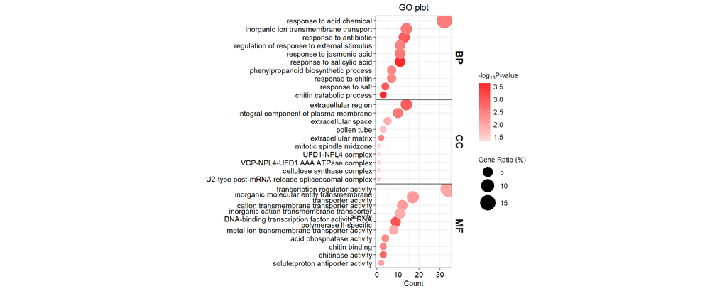

| 选项 | 含义 | 可选范围 |
| --- | --- | --- |
| deglist | 差异基因列表变量 | 必填 |
| eggnogFile | eggNOG-Mapper注释输出的tsv文件路径 | 必填 |
| useFDR | 是否使用FDR作为显著性 具体显著性阈值由cut来定义 | T或F |
| cut | 显著性阈值，当useFDR=T时表示FDR阈值 当useFDR=F时表示Pvalue阈值 | 0~1的小数 |
| outdir | 输出结果目录 | 必填 |
| outprefix | 输出结果文件前缀 | 必填 |

```r
GObubble(dataset = GOresult, onlySig = T, useFDR = F, cut = 0.05, top = 10, MainTitle = "GO plot", TrimTerm = F, TermWidth = 50, ColorScheme = "rw", ColorReverse = F)
```

#### 4.2.1.1 GO二级节点注释条形图

绘制GO数据库的所有二级节点的所有基因与差异基因条形图：

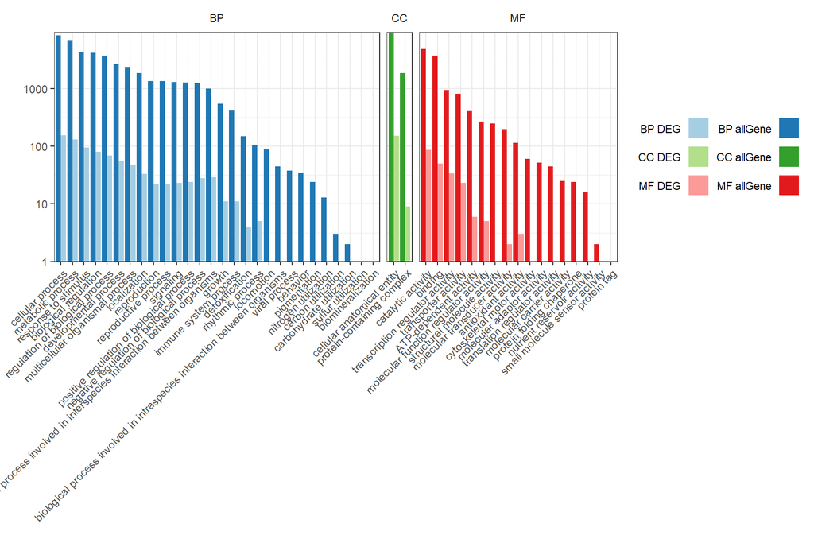

```r
GOBar(deg, eggnog = "demo/demo.eggnog.tsv")
```

### 4.2.2 基于PANNZER2的GO富集

[PANNZER2数据库](http://ekhidna2.biocenter.helsinki.fi/sanspanz/)可以对提交的序列文件进行GO注释，速度快，且注释全面。

下载GO prediction的文件（单击鼠标右键，另存为） ，[示例文件链接](https://github.com/biomarble/PlantNGSTools/tree/main/inst/demo/demo.pannzer.GO.txt)

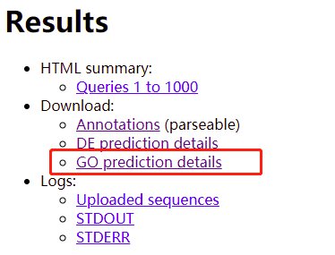

PANNZER2注释结果页面

```r
deg = read.delim("demo/demo.rice.deg.txt", header = F)$V1
GOresult = GOEnrich_pannzer2(deglist = deg, useFDR = F, cut = 0.05, pannzerfile = "demo/demo.pannzer.GO.txt", outdir = "output", outprefix = "Pannzer2.go")
```

```
Processing BP class.........done!
Processing MF class.........done!
Processing CC class.........done!

GO enrichment Done!
Result files saved at:
output/Pannzer2.go.GO.significant.tsv
output/Pannzer2.go.GO.all.tsv
```

```r
GObubble(dataset = GOresult, onlySig = T, useFDR = F, cut = 0.05, top = 10, TrimTerm = F, TermWidth = 50, MainTitle = "GO plot", ColorScheme = "rw", ColorReverse = F)
```

| 选项 | 含义 | 可选范围 |
| --- | --- | --- |
| deglist | 差异基因列表变量 | 必填 |
| pannzerfile | PANNZER2注释输出的GO.out文件路径 | 必填 |
| useFDR | 是否使用FDR作为显著性 具体显著性阈值由cut来定义 | T或F |
| cut | 显著性阈值，当useFDR=T时表示FDR阈值 当useFDR=F时表示Pvalue阈值 | 0~1的小数 |
| outdir | 输出结果目录 | 必填 |
| outprefix | 输出结果文件前缀 | 必填 |

#### 4.2.2.1 GO二级节点注释条形图

绘制GO数据库的所有二级节点的所有基因与差异基因条形图：

```r
GOBar(deg, pannzer2 = "demo/demo.pannzer.GO.txt")
```

### 4.2.3 自主注释的GO富集分析

#### 4.2.3.1 GeneID与GOID对应表: 一对一

如果已有的GO注释格式为：GeneID和GOID一对一，如下所示：

第一列为GeneID，第二列为GOID。

以txt格式存储，列与列之间以tab（制表符）分隔。

| GeneID | GOID |
| --- | --- |
| Pcab132295 | GO:0005247 |
| Pcab132295 | GO:0006821 |
| Pcab132295 | GO:0016021 |
| Pcab132295 | GO:0034220 |
| Pcab132296 | GO:0005247 |
| Pcab132296 | GO:0006821 |
| Pcab132296 | GO:0016021 |
| Pcab132296 | GO:0034220 |
| Pcab142741 | GO:0004601 |
| Pcab142741 | GO:0098869 |

使用`GOEnrich_customTable`函数，`tableFile`定义文件路径：

```r
deg = read.delim("demo/demo.rice.deg.txt", header = F)$V1
GOresult = GOEnrich_customTable(deglist = deg, useFDR = F, cut = 0.05, tableFile = "demo/demo.GOtable.txt", outdir = "output", outprefix = "table.GO")
```

```
Processing BP class.........done!
Processing MF class.........done!
Processing CC class.........done!

GO enrichment Done!
Result files saved at:
output/table.GO.GO.significant.tsv
output/table.GO.GO.all.tsv
```

```r
GObubble(dataset = GOresult, onlySig = T, useFDR = F, cut = 0.05, top = 10, TrimTerm = F, TermWidth = 50, MainTitle = "GO plot", ColorScheme = "rw", ColorReverse = F)
```

| 选项 | 含义 | 可选范围 |
| --- | --- | --- |
| deglist | 差异基因列表变量 | 必填 |
| tableFile | 一对一注释文件路径 | 必填 |
| useFDR | 是否使用FDR作为显著性 具体显著性阈值由cut来定义 | T或F |
| cut | 显著性阈值，当useFDR=T时表示FDR阈值 当useFDR=F时表示Pvalue阈值 | 0~1的小数 |
| outdir | 输出结果目录 | 必填 |
| outprefix | 输出结果文件前缀 | 必填 |

#### 4.2.3.2 GO二级节点注释条形图

绘制GO数据库的所有二级节点的所有基因与差异基因条形图：

```r
GOBar(deg, customTable = "demo/demo.GOtable.txt")
```

#### 4.2.3.3 GeneID与GOID对应表：一对多

如果已有的GO注释格式为：GeneID和GOID一对多，如下所示：

第一列为GeneID，第二列为GOID，其中多个GOID之间以逗号(,)分隔。

以txt格式存储，列与列之间以tab（制表符）分隔。

| GeneID | GOID |
| --- | --- |
| Os01g0100100 | GO:0090630,GO:0005096,GO:0016021,GO:0005507,GO:0006886,GO:0016491 |
| Os01g0100400 | GO:0005507,GO:0046658,GO:0006508,GO:0016491,GO:0009506,GO:0004185,GO:0016021 |
| Os01g0100500 | GO:0005507,GO:0016021,GO:0016491 |
| Os01g0100600 | GO:0003676,GO:0016310,GO:0016301 |
| Os01g0100650 | GO:0016021 |
| Os01g0100700 | GO:0015935,GO:0003735,GO:0006412,GO:0003723,GO:0022626,GO:0000028 |

[示例文件链接](https://github.com/biomarble/PlantNGSTools/tree/main/inst/demo/demo.GOMapping.txt)

使用`GOEnrich_customMapping`函数，`mappingfile`定义文件路径：

```r
deg = read.delim("demo/demo.rice.deg.txt", header = F)$V1
GOresult = GOEnrich_customMapping(deglist = deg, useFDR = F, cut = 0.05, mappingfile = "demo/demo.GOMapping.txt", outdir = "output", outprefix = "map.GO")
```

```
Processing BP class.........done!
Processing MF class.........done!
Processing CC class.........done!

GO enrichment Done!
Result files saved at:
output/map.GO.GO.significant.tsv
output/map.GO.GO.all.tsv
```

```r
GObubble(dataset = GOresult, onlySig = T, useFDR = F, cut = 0.05, top = 10, TrimTerm = F, TermWidth = 50, MainTitle = "GO plot", ColorScheme = "rw", ColorReverse = F)
```

| 选项 | 含义 | 可选范围 |
| --- | --- | --- |
| deglist | 差异基因列表变量 | 必填 |
| mappingfile | 一对多的注释文件路径 | 必填 |
| useFDR | 是否使用FDR作为显著性 具体显著性阈值由cut来定义 | T或F |
| cut | 显著性阈值，当useFDR=T时表示FDR阈值 当useFDR=F时表示Pvalue阈值 | 0~1的小数 |
| outdir | 输出结果目录 | 必填 |
| outprefix | 输出结果文件前缀 | 必填 |

#### 4.2.3.4 GO二级节点注释条形图

绘制GO数据库的所有二级节点的所有基因与差异基因条形图：

```r
GOBar(deg, customMapping = "demo/demo.GOMapping.txt")
```

### 4.2.4 基于blastkoala的KEGG富集

[blastkoala](https://www.kegg.jp/blastkoala/)工具可以将上传的序列与KEGG数据库中的序列进行blast比对，得到GeneID的对应关系（GeneID->K number），进而得到GeneID与KEGG Pathway的对应关系。

第一列为GeneID，第二列为K number，文件以txt格式存储，列与列之间以tab（制表符）分隔，无表头。 如下表所示：

| Pcab047734 |  |
| --- | --- |
| Pcab047735 |  |
| Pcab047736 |  |
| Pcab047737 |  |
| Pcab047738 |  |
| Pcab047748 | K11649 |

[示例文件链接](https://github.com/biomarble/PlantNGSTools/tree/main/inst/demo/demo.blastkoala.txt)

使用`KEGGenrich_blastkoala`函数，以`blastkoalafile`定义下载的文件路径：

```r
deg = read.delim("demo/demo.rice.deg.txt", header = F)$V1
KEGGresult = KEGGenrich_blastkoala(deglist = deg, useFDR = F, blastkoalafile = "demo/demo.blastkoala.txt", outdir = "output", outprefix = "blastkoala")
```

```
Enrichment Done! Result files saved:
output/blastkoala.tsv
output/blastkoala.html
```

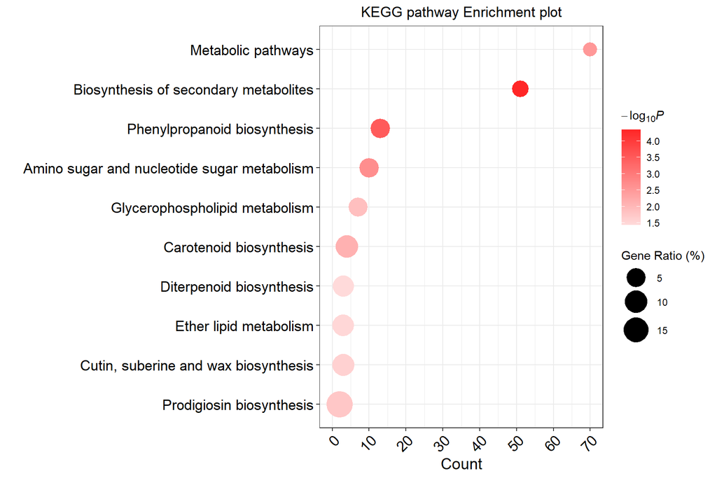

| 选项 | 含义 | 可选范围 |
| --- | --- | --- |
| deglist | 差异基因列表变量 | 必填 |
| blastkoalafile | blastkoala注释输出文件路径 | 必填 |
| useFDR | 是否输出FDR值 | T或F |
| outdir | 输出结果目录 | 必填 |
| outprefix | 输出结果文件前缀 | 必填 |

```r
KEGGbubble(dataset = KEGGresult, top = 10, MainTitle = "KEGG pathway Enrichment plot", xangle = 45, ColorScheme = "rw", ColorReverse = F)
```